# Research Questions

A Kenyan entrepreneur has created an online cryptography course and would want to advertise it on her blog. She currently targets audiences originating from various countries. In the past, she ran ads to advertise a related course on the same blog and collected data in the process. She would now like to employ your services as a Data Science Consultant to help her identify which individuals are most likely to click on her ads.

# Problem Statement

Create a prediction model that more accurately predicts whether a user will click an Ad or not.

# Metrics of success

The accuracy score of the model will be used to measure the predictive power of the model.

### Experimental Design

1.Loading Data

2.Checking the Data

3.Data Cleaning

4.Exploratory Analysis

5.Implementing the Solution

6.Challenging the solution

7.Follow up questions

## Instaling Libaries

```r
## Instaling the relvant libaries
install.packages("remotes")
install.packages("pacman")
install.packages("gmodels")
install.packages("outliers")
install.packages("tidyverse")
install.packages("xgboost")
```

```r
install.packages("corrplot")
install.packages("ggplot2")
install.packages("ggcorrplot")
install.packages("caret")
install.packages("class")
install.packages("lattice")
```

## Importing Libaries

```r
# Importing the relvant libaries

library(remotes)
library(pacman)
library(gmodels)
library(outliers)
library(tidyverse)
library(xgboost)
```

```r
library(corrplot)
library(ggplot2)
library(caret)
library(class)
library(ggcorrplot)

library("data.table")
theme_set(theme_classic())
options(warn = -1)
```

## Loading Data

```r
### Loading dataset
df <- fread('http://bit.ly/IPAdvertisingData')
```

## Checking the Data

```r
### preview of first six
head(df)
```

```
##    Daily Time Spent on Site Age Area Income Daily Internet Usage
## 1:                    68.95  35    61833.90               256.09
## 2:                    80.23  31    68441.85               193.77
## 3:                    69.47  26    59785.94               236.50
## 4:                    74.15  29    54806.18               245.89
## 5:                    68.37  35    73889.99               225.58
## 6:                    59.99  23    59761.56               226.74
##                            Ad Topic Line           City Male    Country
## 1:    Cloned 5thgeneration orchestration    Wrightburgh    0    Tunisia
## 2:    Monitored national standardization      West Jodi    1      Nauru
## 3:      Organic bottom-line service-desk       Davidton    0 San Marino
## 4: Triple-buffered reciprocal time-frame West Terrifurt    1      Italy
## 5:         Robust logistical utilization   South Manuel    0    Iceland
## 6:       Sharable client-driven software      Jamieberg    1     Norway
##              Timestamp Clicked on Ad
## 1: 2016-03-27 00:53:11             0
## 2: 2016-04-04 01:39:02             0
## 3: 2016-03-13 20:35:42             0
## 4: 2016-01-10 02:31:19             0
## 5: 2016-06-03 03:36:18             0
## 6: 2016-05-19 14:30:17             0
```

```r
### Getting the column names
attributes(df)$names
```

```
##  [1] "Daily Time Spent on Site" "Age"
##  [3] "Area Income"              "Daily Internet Usage"
##  [5] "Ad Topic Line"            "City"
##  [7] "Male"                     "Country"
##  [9] "Timestamp"                "Clicked on Ad"
```

```r
### Getting the class ofthe data
attributes(df)$class
```

```
## [1] "data.table" "data.frame"
```

```r
### Taking a glimpse on some of the data in the dataframe
glimpse(df)
```

```
## Rows: 1,000
## Columns: 10
## $ `Daily Time Spent on Site` <dbl> 68.95, 80.23, 69.47, 74.15, 68.37, 59.99...
## $ Age                        <int> 35, 31, 26, 29, 35, 23, 33, 48, 30, 20, ...
## $ `Area Income`              <dbl> 61833.90, 68441.85, 59785.94, 54806.18, ...
## $ `Daily Internet Usage`     <dbl> 256.09, 193.77, 236.50, 245.89, 225.58, ...
## $ `Ad Topic Line`            <chr> "Cloned 5thgeneration orchestration", "M...
## $ City                       <chr> "Wrightburgh", "West Jodi", "Davidton", ...
## $ Male                       <int> 0, 1, 0, 1, 0, 1, 0, 1, 1, 1, 0, 1, 1, 0...
## $ Country                    <chr> "Tunisia", "Nauru", "San Marino", "Italy...
## $ Timestamp                  <chr> "2016-03-27 00:53:11", "2016-04-04 01:39...
## $ `Clicked on Ad`            <int> 0, 0, 0, 0, 0, 0, 0, 1, 0, 0, 1, 0, 1, 0...
```

```r
### Checking some statistical summaries of the data
summary(df)
```

```
##  Daily Time Spent on Site      Age         Area Income    Daily Internet Usage
##  Min.   :32.60            Min.   :19.00   Min.   :13996   Min.   :104.8
##  1st Qu.:51.36            1st Qu.:29.00   1st Qu.:47032   1st Qu.:138.8
##  Median :68.22            Median :35.00   Median :57012   Median :183.1
##  Mean   :65.00            Mean   :36.01   Mean   :55000   Mean   :180.0
##  3rd Qu.:78.55            3rd Qu.:42.00   3rd Qu.:65471   3rd Qu.:218.8
##  Max.   :91.43            Max.   :61.00   Max.   :79485   Max.   :270.0
##  Ad Topic Line          City                Male         Country
##  Length:1000        Length:1000        Min.   :0.000   Length:1000
##  Class :character   Class :character   1st Qu.:0.000   Class :character
##  Mode  :character   Mode  :character   Median :0.000   Mode  :character
##                                        Mean   :0.481
##                                        3rd Qu.:1.000
##                                        Max.   :1.000
##   Timestamp         Clicked on Ad
##  Length:1000        Min.   :0.0
##  Class :character   1st Qu.:0.0
##  Mode  :character   Median :0.5
##                     Mean   :0.5
##                     3rd Qu.:1.0
##                     Max.   :1.0
```

```r
### Checking for the dimensions of the dataframe
dim(df)
```

```
## [1] 1000   10
```

Our data contains ten columns and 1000 rows

```r
### Checking the number of unique columns
cat.columns <- c("Ad Topic Line","City","Country","Timestamp")
no <- function(x) {
    nlevels(x)
  }

number <- sapply(select(df, cat.columns), no)
```

```
## Note: Using an external vector in selections is ambiguous.
## i Use `all_of(cat.columns)` instead of `cat.columns` to silence this message.
## i See <https://tidyselect.r-lib.org/reference/faq-external-vector.html>.
```

```r
number
```

```
## Ad Topic Line          City       Country     Timestamp
##             0             0             0             0
```

```r
### Summary of numeric columns


df %>%
  select_if(is.numeric) %>%
  map(~summary(.))
```

```
## $`Daily Time Spent on Site`
##    Min. 1st Qu.  Median    Mean 3rd Qu.    Max.
##   32.60   51.36   68.22   65.00   78.55   91.43
##
## $Age
##    Min. 1st Qu.  Median    Mean 3rd Qu.    Max.
##   19.00   29.00   35.00   36.01   42.00   61.00
##
## $`Area Income`
##    Min. 1st Qu.  Median    Mean 3rd Qu.    Max.
##   13996   47032   57012   55000   65471   79485
##
## $`Daily Internet Usage`
##    Min. 1st Qu.  Median    Mean 3rd Qu.    Max.
##   104.8   138.8   183.1   180.0   218.8   270.0
##
## $Male
##    Min. 1st Qu.  Median    Mean 3rd Qu.    Max.
##   0.000   0.000   0.000   0.481   1.000   1.000
##
## $`Clicked on Ad`
##    Min. 1st Qu.  Median    Mean 3rd Qu.    Max.
##     0.0     0.0     0.5     0.5     1.0     1.0
```

For each numeric column we have Minmum, Quatile, Median, Mean 3rd Quartile and Maximum

# Data Cleaning

```r
### Changing the names of the columns to lower

colnames(df) <- tolower(str_replace_all(colnames(df), c(' ' = '_')))
colnames(df)
```

```
##  [1] "daily_time_spent_on_site" "age"
##  [3] "area_income"              "daily_internet_usage"
##  [5] "ad_topic_line"            "city"
##  [7] "male"                     "country"
##  [9] "timestamp"                "clicked_on_ad"
```

```r
### The male column should be renamed to gender

colnames(df)[colnames(df) == 'male'] = 'gender'
```

```r
### Changing time stamp to date time series
### specify format m/d/Y H:M:S
### convert the characters of date and time to  date time series
df$timestamp <- as.POSIXct(df$timestamp, format="%Y-%m-%d %H:%M:%S",tz=Sys.timezone())
```

```r
### Checking for Missing values

colSums(is.na(df))
```

```
## daily_time_spent_on_site                      age              area_income
##                        0                        0                        0
##     daily_internet_usage            ad_topic_line                     city
##                        0                        0                        0
##                   gender                  country                timestamp
##                        0                        0                        0
##            clicked_on_ad
##                        0
```

No missing values in the dataset

```r
### Checking for duplicates

anyDuplicated(df)
```

```
## [1] 0
```

We observe zero duplicated values meaning no duplicates

```r
###Frequency tables clicked_on_ad

table(df$clicked_on_ad)
```

```
##
##   0   1
## 500 500
```

From clicked on ad colum we observe the number of clicked and not clicked are equal distributed

```r
### remaning the target column
df$clicked_on_ad <- ifelse(df$clicked_on_ad == 1,"Yes","No")
table(df$clicked_on_ad)
```

```
##
##  No Yes
## 500 500
```

```r
### Frequency tables gender

table(df$gender)
```

```
##
##   0   1
## 519 481
```

From gender 1 represents male and 0 represent female. Females have high number than male.

### Boxplots

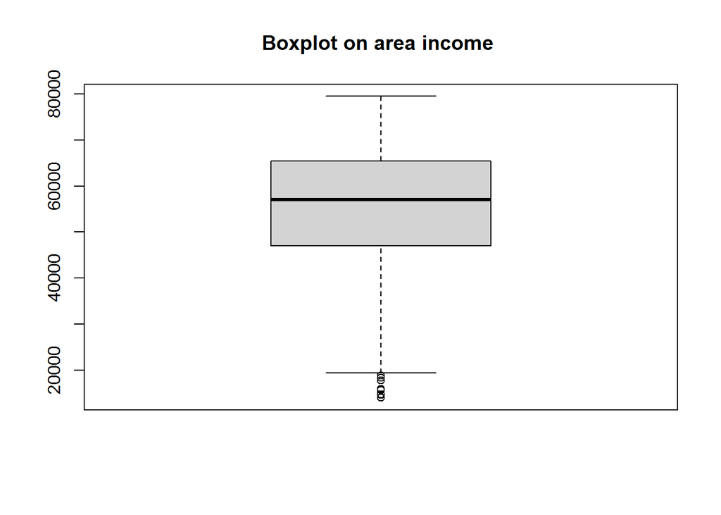

```r
### Checking Outliers using boxplots on area income

boxplot(df$area_income,main = "Boxplot on area income ")
```

From the above boxplot we can observe area of income has some outliers

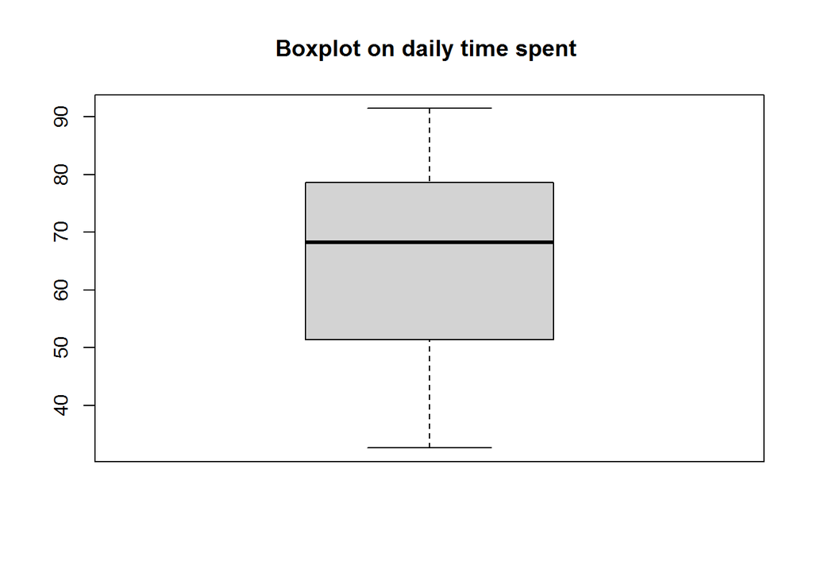

```r
### Checking outliers using boxplots on daily time spent on site

boxplot(df$daily_time_spent_on_site,main = "Boxplot on daily time spent ")
```

The above shows no outliers on the daily time spent on site.

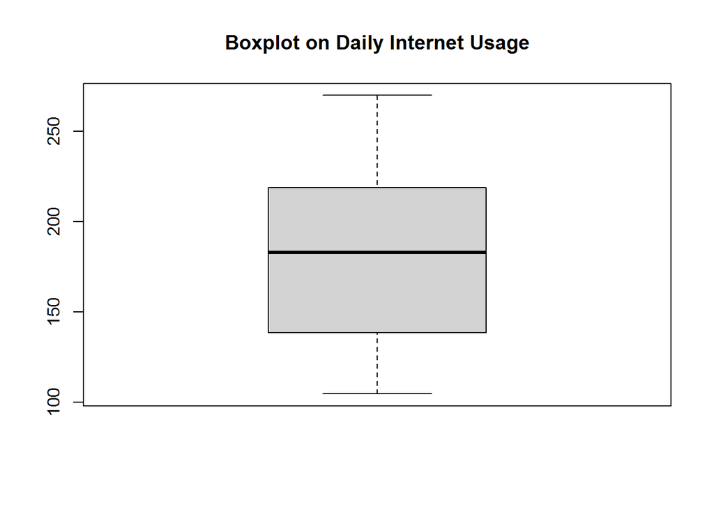

```r
### Plotting boxplots on  Daily Internet Usage

boxplot(df$daily_internet_usage,main = "Boxplot on Daily Internet Usage")
```

The above shows no outliers on the daily internet usage

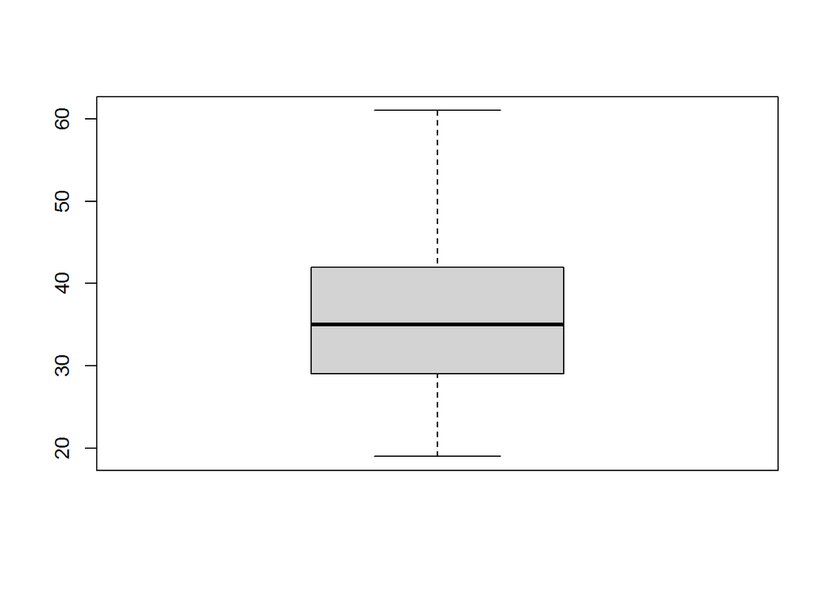

```r
### Plotting boxplots on Age

boxplot(df$age)
```

From the above boxplot we can observe age has no outliers

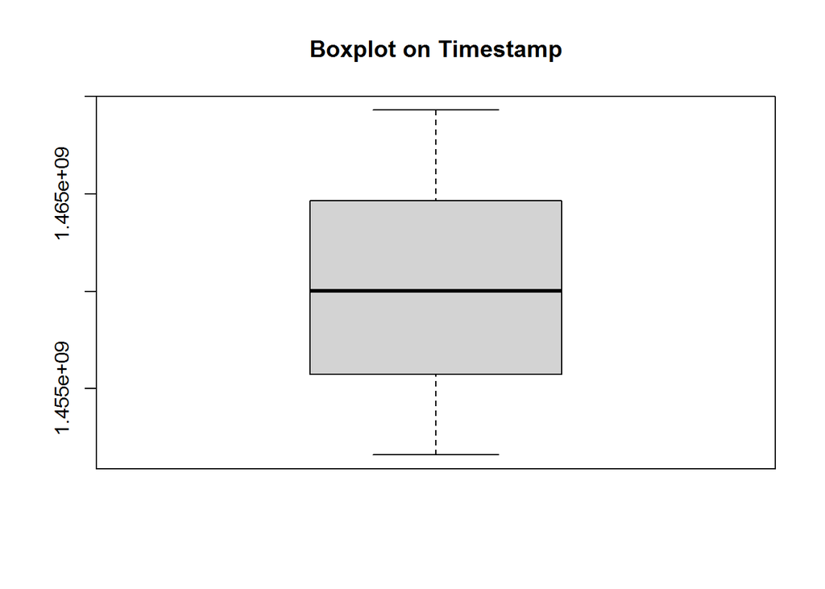

```r
### Plotting boxplots on  Daily Internet Usage
boxplot(df$timestamp,main = "Boxplot on Timestamp")
```

```r
### cheacking for unique
unique_items <- unique(df)
unique_items
```

```
##       daily_time_spent_on_site age area_income daily_internet_usage
##    1:                    68.95  35    61833.90               256.09
##    2:                    80.23  31    68441.85               193.77
##    3:                    69.47  26    59785.94               236.50
##    4:                    74.15  29    54806.18               245.89
##    5:                    68.37  35    73889.99               225.58
##   ---
##  996:                    72.97  30    71384.57               208.58
##  997:                    51.30  45    67782.17               134.42
##  998:                    51.63  51    42415.72               120.37
##  999:                    55.55  19    41920.79               187.95
## 1000:                    45.01  26    29875.80               178.35
##                               ad_topic_line           city gender
##    1:    Cloned 5thgeneration orchestration    Wrightburgh      0
##    2:    Monitored national standardization      West Jodi      1
```

[output cut: 21 more lines]

# Exploratory Data Analysis

## Univariate

### Measures of Central Tendency

### Mean

```r
### Mean daily_internet_usage

Advatatisment.InternetUsage.mean <- mean(df$daily_internet_usage)
Advatatisment.InternetUsage.mean
```

```
## [1] 180.0001
```

```r
### Mean area_income

Advatatisment.area_income.mean <- mean(df$area_income)
Advatatisment.area_income.mean
```

```
## [1] 55000
```

```r
### Mean of Age

Advatatisment.Age.mean <- mean(df$age)
Advatatisment.Age.mean
```

```
## [1] 36.009
```

### Median

```r
### Median daily_internet_usage

daily_internet_usage.median <- median(df$daily_internet_usage)
daily_internet_usage.median
```

```
## [1] 183.13
```

```r
### Median area_income median

Advatatisment.area_income.median <- median(df$area_income)
Advatatisment.area_income.median
```

```
## [1] 57012.3
```

```r
### Median Age.median

Advatatisment.Age.median <- median(df$age)
Advatatisment.Age.median
```

```
## [1] 35
```

```r
### Median of Daily_Internet_Usage

Advatatisment_InternetUsage_mean <- mean(df$daily_internet_usage)
Advatatisment_InternetUsage_mean
```

```
## [1] 180.0001
```

### Barplots

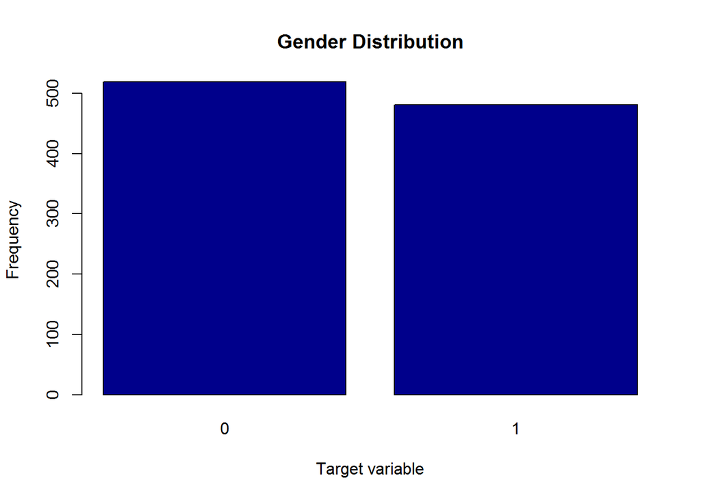

```r
###Plotting barplots of the Genser column

counts <- table(df$gender)
barplot(counts, main="Gender Distribution",xlab="Target variable",ylab = "Frequency",col="darkblue")
```

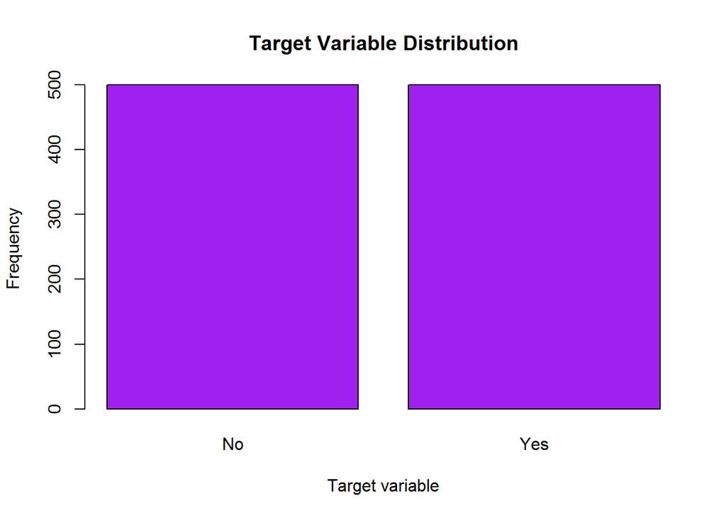

```r
### Plotting barplots of the target column

counts <- table(df$clicked_on_ad)
barplot(counts, main="Target Variable Distribution",xlab="Target variable",ylab = "Frequency",col="purple")
```

Our target varialbe is evenly distributed.

### Density plot

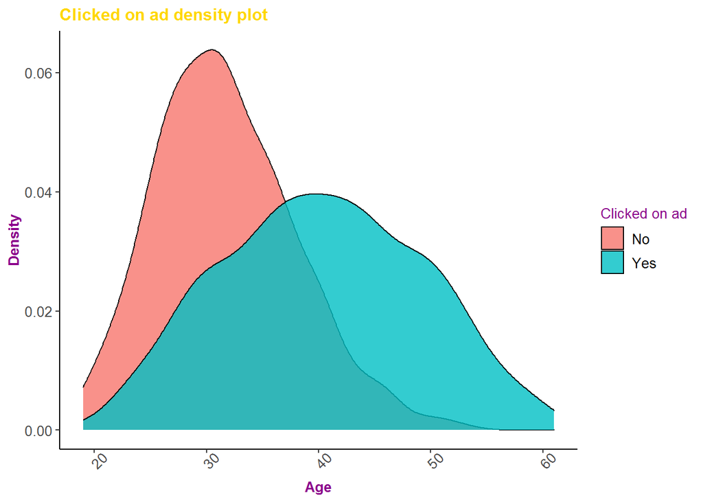

```r
### Plotting density plot

options(repr.plot.width = 10, repr.plot.height = 7)
p1 = ggplot(data = df, aes(age)) +
        geom_density(aes(fill=factor(clicked_on_ad)), alpha = 0.8) +
        labs(title = 'Clicked on ad density plot', x = 'Age', y = 'Density', fill = 'Clicked on ad') +
        scale_color_brewer(palette = 'Set1') +
        theme(plot.title = element_text(size = 12, face = 'bold', color = 'gold'),
             axis.title.x = element_text(size = 10, face = 'bold', color = 'darkmagenta'),
             axis.title.y = element_text(size = 10, face = 'bold', color = 'darkmagenta'),
             axis.text.x = element_text(size = 10, angle = 45),
             axis.text.y = element_text(size = 10),
             legend.title = element_text(size = 10, color = 'darkmagenta'),
             legend.text = element_text(size = 10))
plot(p1)
```

Density plot of clicked add and not clicked not clicked having high distribution.

### Frequency polygon

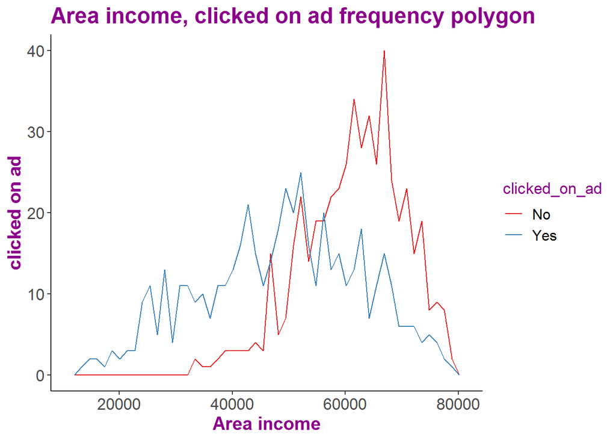

```r
### Frequency polygon

options(repr.plot.width = 13, repr.plot.height = 7)
ggplot(data = df, aes(x = area_income, col = clicked_on_ad))+
    geom_freqpoly(bins = 50)+
    labs(title = 'Area income, clicked on ad frequency polygon', x = 'Area income', y = 'clicked on ad', fill = 'Clicked on ad') +
        scale_color_brewer(palette = 'Set1') +
        theme(plot.title = element_text(size = 18, face = 'bold', color = 'darkmagenta'),
             axis.title.x = element_text(size = 15, face = 'bold', color = 'darkmagenta'),
             axis.title.y = element_text(size = 15, face = 'bold', color = 'darkmagenta'),
             axis.text.x = element_text(size = 13),
             axis.text.y = element_text(size = 13),
             legend.title = element_text(size = 13, color = 'darkmagenta'),
             legend.text = element_text(size = 12))
```

From the above we can observe as the in come increases the number of not clicked tend to increase

### Plotting boxplots

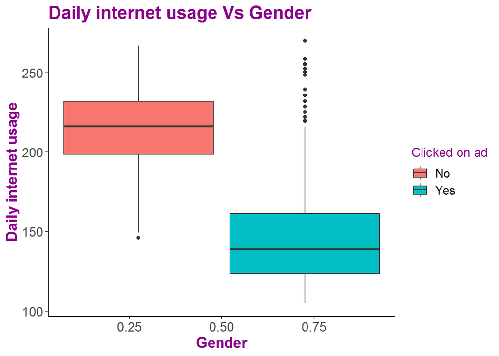

```r
### Plotting boxplots

options(repr.plot.width = 13, repr.plot.height = 7)
ggplot(data = df, aes(x = gender, y = daily_internet_usage)) +
    geom_boxplot(aes(fill = factor(clicked_on_ad))) +
    labs(title = 'Daily internet usage Vs Gender', y = 'Daily internet usage', x = 'Gender', fill = 'Clicked on ad') +
    scale_color_brewer(palette = 'Set1') +
    theme(plot.title = element_text(size = 18, face = 'bold', color = 'darkmagenta'),
             axis.title.x = element_text(size = 15, face = 'bold', color = 'darkmagenta'),
             axis.title.y = element_text(size = 15, face = 'bold', color = 'darkmagenta'),
             axis.text.x = element_text(size = 13),
             axis.text.y = element_text(size = 13),
             legend.title = element_text(size = 13, color = 'darkmagenta'),
             legend.text = element_text(size = 12))
```

### Histograms

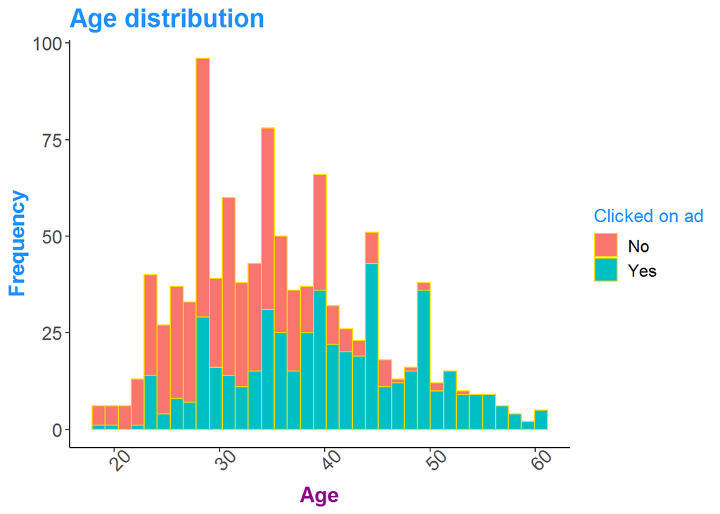

```r
### Plotting a a pair of histograms

options(repr.plot.width = 13, repr.plot.height = 7)
ggplot(data = df, aes(x = age, fill = clicked_on_ad))+
    geom_histogram(bins = 35, color = 'gold') +
    labs(title = 'Age distribution', x = 'Age', y = 'Frequency', fill = 'Clicked on ad') +
        scale_color_brewer(palette = 'Set1') +
        theme(plot.title = element_text(size = 18, face = 'bold', color = 'dodgerblue'),
             axis.title.x = element_text(size = 15, face = 'bold', color = 'darkmagenta'),
             axis.title.y = element_text(size = 15, face = 'bold', color = 'dodgerblue'),
             axis.text.x = element_text(size = 13, angle = 45),
             axis.text.y = element_text(size = 13),
             legend.title = element_text(size = 13, color = 'dodgerblue'),
             legend.text = element_text(size = 12))
```

### Barchart

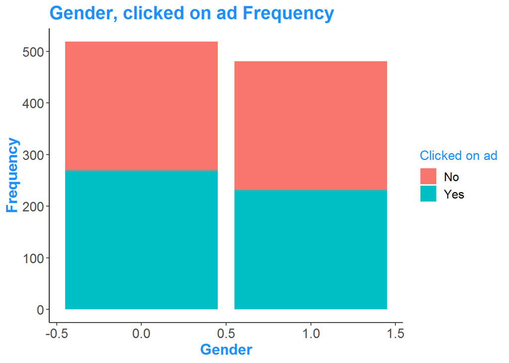

```r
### Barcharts to check for frequencies of features

options(repr.plot.width = 13, repr.plot.height = 7)
ggplot(data = df, aes(x = gender))+
    geom_bar(aes(fill = clicked_on_ad))+
    labs(title = 'Gender, clicked on ad Frequency', y = 'Frequency', x = 'Gender', fill = 'Clicked on ad') +
    scale_color_brewer(palette = 'Set1') +
    theme(plot.title = element_text(size = 18, face = 'bold', color = 'dodgerblue'),
             axis.title.x = element_text(size = 15, face = 'bold', color = 'dodgerblue'),
             axis.title.y = element_text(size = 15, face = 'bold', color = 'dodgerblue'),
             axis.text.x = element_text(size = 13),
             axis.text.y = element_text(size = 13),
             legend.title = element_text(size = 13, color = 'dodgerblue'),
             legend.text = element_text(size = 12))
```

Male represented by 1.0 has less click than female

```r
### remaning the target column
df$clicked_on_ad <- ifelse(df$clicked_on_ad == "Yes",1,0)
table(df$clicked_on_ad)
```

```
##
##   0   1
## 500 500
```

```r
### Insatalling moments
install.packages("moments")
### loading laibrary moments
library(moments)
```

### Correlation

```r
### Getting the correlation between the numeric variables

corr_df <- cor(select(df,c("daily_time_spent_on_site","age","area_income","clicked_on_ad")))
corr_df
```

```
##                          daily_time_spent_on_site        age area_income
## daily_time_spent_on_site                1.0000000 -0.3315133   0.3109544
## age                                    -0.3315133  1.0000000  -0.1826050
## area_income                             0.3109544 -0.1826050   1.0000000
## clicked_on_ad                          -0.7481166  0.4925313  -0.4762546
##                          clicked_on_ad
## daily_time_spent_on_site    -0.7481166
## age                          0.4925313
## area_income                 -0.4762546
## clicked_on_ad                1.0000000
```

Their is an correlation with the selected features.

### Kurtosis

```r
### Kurtosis of column age
kurtosis(corr_df)
```

```
## daily_time_spent_on_site                      age              area_income
##                 1.610318                 1.438932                 1.720108
##            clicked_on_ad
##                 1.304527
```

### Skewness

```r
### Skewness of column age
skewness(corr_df)
```

```
## daily_time_spent_on_site                      age              area_income
##                0.2327146                0.2885240                0.4104749
##            clicked_on_ad
##                0.1311875
```

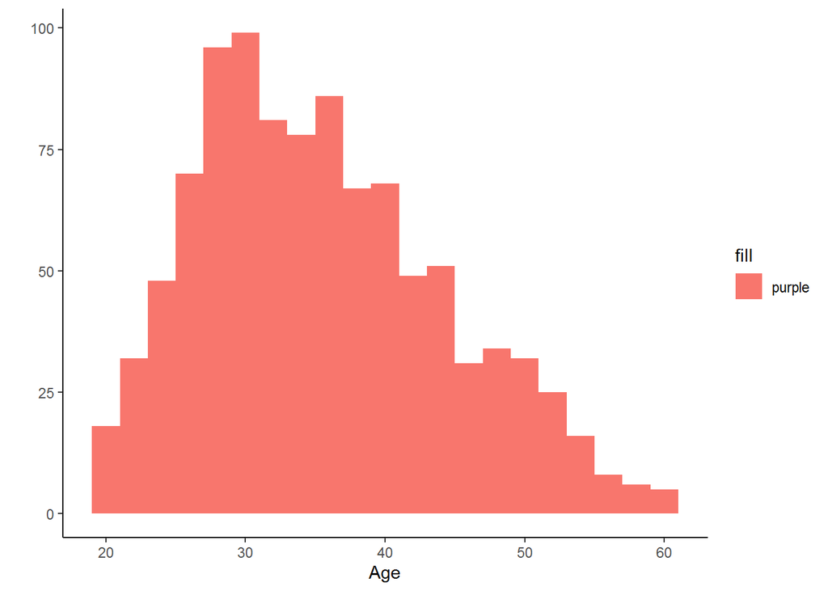

```r
qplot(df$age, geom = 'histogram', fill = 'purple', binwidth = 2) + xlab('Age')
```

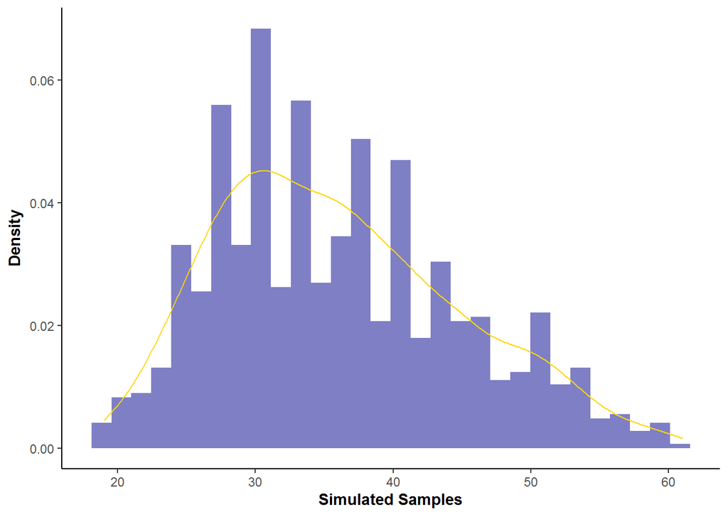

```r
datasim <- data.frame(df$age)
ggplot(datasim, aes(x = df$age), binwidth = 2) +
       geom_histogram(aes(y = ..density..), fill = 'darkblue', alpha = 0.5) +
       geom_density(colour = 'gold') + xlab(expression(bold('Simulated Samples'))) +
       ylab(expression(bold('Density')))
```

### Correlation plot

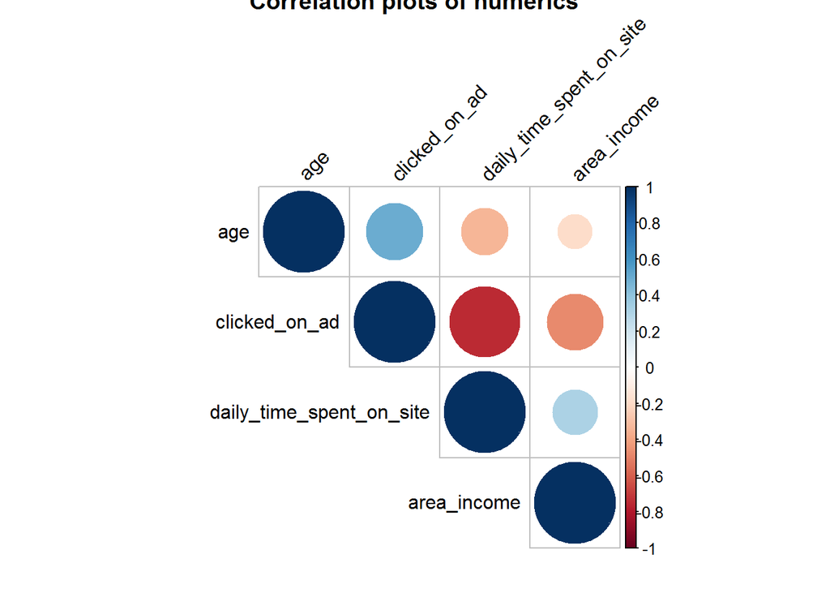

```r
### Showing correlation using correlation plot

corrplot(corr_df, type = "upper", order = "hclust",
         tl.col = "black", tl.srt = 45,main="Correlation plots of numerics")
```

### Correlation heatmap

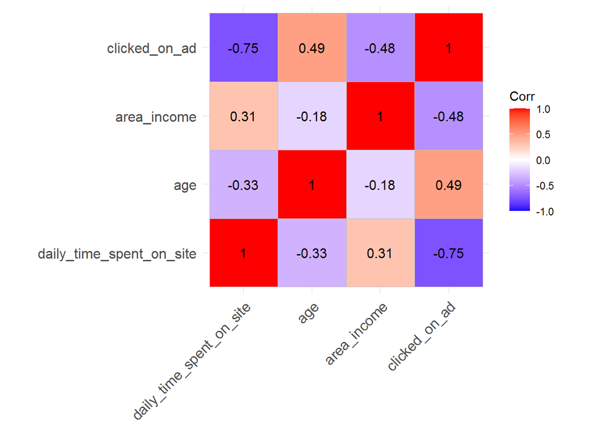

```r
### Plotting heatmap to get more correlation

col<- colorRampPalette(20)
ggcorrplot(round(corr_df, 2),lab = T)
```

### Scatter plot

[figure not shown]

```r
### Plotting a scatter plot between variables

plot(df$area_income, df$age, main="Scatterplot Age VS Daily Time spent",
   xlab="Age ", ylab="Daily Time Spent ", pch=19)
```

### Histogram

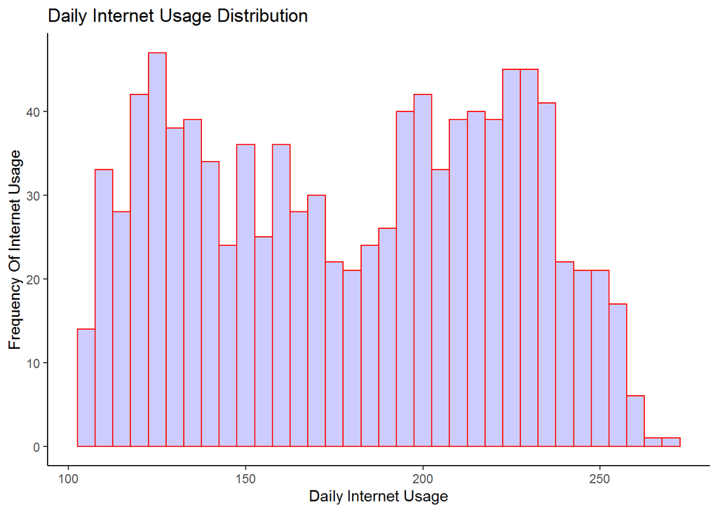

```r
### Plotting a histogram of daily internet Used

qplot(df$daily_internet_usage,main = "Daily Internet Usage Distribution",geom="histogram",
    xlab = "Daily Internet Usage",ylab = "Frequency Of Internet Usage",binwidth = 5,fill=I("blue"),col=I("red"), alpha=I(.2),)
```

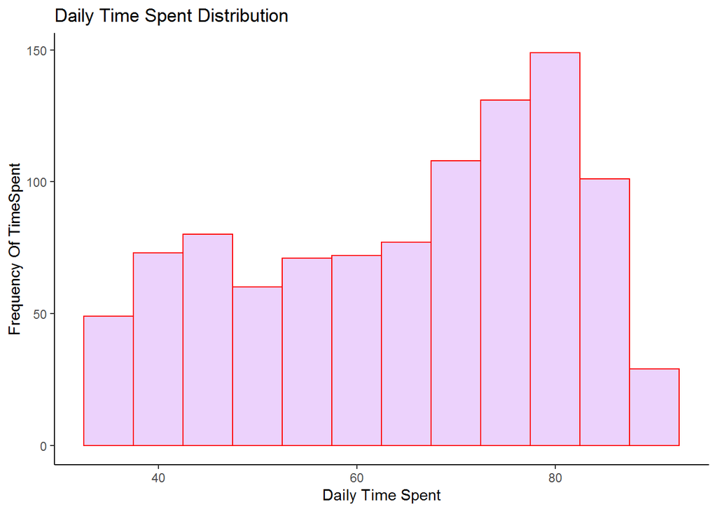

```r
### Plotting a histogram of daily Time Spent

qplot(df$daily_time_spent_on_site,main = "Daily Time Spent Distribution",geom="histogram",
    xlab = "Daily Time Spent",ylab = "Frequency Of TimeSpent",binwidth = 5,fill=I("purple"),col=I("red"), alpha=I(.2),)
```

Increase in daily time spent increases as frequency of time spent increase

# Modelling

```r
### remaning the target column
df$clicked_on_ad <- ifelse(df$clicked_on_ad == 1,"Yes","No")
table(df$clicked_on_ad)
```

```
##
##  No Yes
## 500 500
```

```r
### Splitting the data into training and testing sets
### Setting the seed to 100, for reproducibility

set.seed(100)
```

```r
### Selecting only columns that are relevant to modeling

mod_cols = c('daily_time_spent_on_site', 'age', 'area_income', 'daily_internet_usage', 'gender', 'clicked_on_ad')
df = select(df, mod_cols)
```

```
## Note: Using an external vector in selections is ambiguous.
## i Use `all_of(mod_cols)` instead of `mod_cols` to silence this message.
## i See <https://tidyselect.r-lib.org/reference/faq-external-vector.html>.
```

```r
### Splitting the data into 80% training and 20% testing
train_rows = createDataPartition(df$clicked_on_ad, p=0.8, list=FALSE)
```

```r
### Creating the training  dataset

train = df[train_rows,]
```

```r
### Creating the test dataset

test = df[-train_rows,]
```

```r
### Creating the  X and Y variables

x = train
y = train$clicked_on_ad
```

```r
### List of some of the available models

paste(names(getModelInfo())[1:50],collapse = ",  ")
```

```
## [1] "ada,  AdaBag,  AdaBoost.M1,  adaboost,  amdai,  ANFIS,  avNNet,  awnb,  awtan,  bag,  bagEarth,  bagEarthGCV,  bagFDA,  bagFDAGCV,  bam,  bartMachine,  bayesglm,  binda,  blackboost,  blasso,  blassoAveraged,  bridge,  brnn,  BstLm,  bstSm,  bstTree,  C5.0,  C5.0Cost,  C5.0Rules,  C5.0Tree, …
```

### Training the model with Adaboost

```r
set.seed(100)
# Training the model using adaboost
model_adaboost = train(clicked_on_ad ~ ., data=train, method='adaboost', tuneLength=2)
model_adaboost
```

```
## AdaBoost Classification Trees
##
## 800 samples
##   5 predictor
##   2 classes: 'No', 'Yes'
##
## No pre-processing
## Resampling: Bootstrapped (25 reps)
## Summary of sample sizes: 800, 800, 800, 800, 800, 800, ...
## Resampling results across tuning parameters:
##
##   nIter  method         Accuracy   Kappa
##    50    Adaboost.M1    0.9541898  0.9082149
##    50    Real adaboost  0.9586492  0.9171596
##   100    Adaboost.M1    0.9554341  0.9107117
##   100    Real adaboost  0.9593608  0.9185739
##
## Accuracy was used to select the optimal model using the largest value.
## The final values used for the model were nIter = 100 and method = Real adaboost.
```

```r
install.packages('e1071', dependencies=TRUE)
```

### Training the model with earth

```r
### Training the model


model = train(clicked_on_ad ~ ., data = train, method = 'earth')
# Making predictions using the training set
pred = predict(model)
```

```r
# Displaying the parameters and their values in the model
model
```

```
## Multivariate Adaptive Regression Spline
##
## 800 samples
##   5 predictor
##   2 classes: 'No', 'Yes'
##
## No pre-processing
## Resampling: Bootstrapped (25 reps)
## Summary of sample sizes: 800, 800, 800, 800, 800, 800, ...
## Resampling results across tuning parameters:
##
##   nprune  Accuracy   Kappa
##    2      0.8946622  0.7890641
##    6      0.9610334  0.9219453
##   11      0.9616254  0.9231122
##
## Tuning parameter 'degree' was held constant at a value of 1
## Accuracy was used to select the optimal model using the largest value.
## The final values used for the model were nprune = 11 and degree = 1.
```

```r
### Previewing the first six predictions
y_pred = predict(model, test)
head(y_pred)
```

```
## [1] No  No  Yes No  Yes Yes
## Levels: No Yes
```

### Training the model with Random Forest

```r
set.seed(100)

# Train the model using rf
model_rf = train(clicked_on_ad ~ ., data=train, method='rf', tuneLength=5)
model_rf
```

```
## Random Forest
##
## 800 samples
##   5 predictor
##   2 classes: 'No', 'Yes'
##
## No pre-processing
## Resampling: Bootstrapped (25 reps)
## Summary of sample sizes: 800, 800, 800, 800, 800, 800, ...
## Resampling results across tuning parameters:
##
##   mtry  Accuracy   Kappa
##   2     0.9599110  0.9196802
##   3     0.9579810  0.9158179
##   4     0.9521547  0.9041369
##   5     0.9474500  0.8946981
##
## Accuracy was used to select the optimal model using the largest value.
## The final value used for the model was mtry = 2.
```

```r
### This is a list of some of the available models

paste(names(getModelInfo())[50:100],collapse = ",  ")
```

```
## [1] "FH.GBML,  FIR.DM,  foba,  FRBCS.CHI,  FRBCS.W,  FS.HGD,  gam,  gamboost,  gamLoess,  gamSpline,  gaussprLinear,  gaussprPoly,  gaussprRadial,  gbm_h2o,  gbm,  gcvEarth,  GFS.FR.MOGUL,  GFS.LT.RS,  GFS.THRIFT,  glm.nb,  glm,  glmboost,  glmnet_h2o,  glmnet,  glmStepAIC,  gpls,  hda,  hdda,  h…
```

### Training the model with KNN

```r
set.seed(100)

# Train the model using knn
model_knn = train(clicked_on_ad ~ ., data=train, method='knn', tuneLength=5)
model_knn
```

```
## k-Nearest Neighbors
##
## 800 samples
##   5 predictor
##   2 classes: 'No', 'Yes'
##
## No pre-processing
## Resampling: Bootstrapped (25 reps)
## Summary of sample sizes: 800, 800, 800, 800, 800, 800, ...
## Resampling results across tuning parameters:
##
##   k   Accuracy   Kappa
##    5  0.6596308  0.3189732
##    7  0.6677881  0.3349859
##    9  0.6726041  0.3448056
##   11  0.6784230  0.3564048
##   13  0.6786638  0.3571579
##
## Accuracy was used to select the optimal model using the largest value.
## The final value used for the model was k = 13.
```

```r
### Making predictions using the training set

pred1 = predict(model_knn)
head(pred1)
```

```
## [1] No  No  No  No  No  Yes
## Levels: No Yes
```